# 1D-Bifurcations (Assignment Sheet 6)

Introduction To Chaos Applied To Systems, Processes And Products (ETSIDI, UPM)

Alfonso Allen-Perkins, Juan Carlos Bueno and Eduardo Faleiro

2025-04-03

# Introduction

Bifurcation theory describes how the qualitative behavior of equilibria changes as a system parameter varies. Here we explore different types of bifurcations using R.

Required Libraries

```r
library(ggplot2)
```

# 1. Supercritical pitchfork bifurcation

## **1.1 Theoretical background**

A **supercritical pitchfork bifurcation** occurs when a stable equilibrium splits into two new stable equilibria as the control parameter $r$ crosses a critical value. The system under study is:

$$\begin{aligned}
\dot{x} &= r \cdot x - x^3
\end{aligned}$$

The fixed points of this system are:

$$x^* = 0, \quad \pm\sqrt{r}$$

The number and stability of fixed points depend on the value of $r$:

- **Case A**: $r < 0$ → Only one stable fixed point at $x = 0$.
- **Case B**: $r = 0$ → Bifurcation point where stability changes.
- **Case C**: $r > 0$ → The origin becomes unstable, and two new stable fixed points appear.

## **1.2 Phase portraits for different $r$**

By plotting $\dot{x}$ versus $x$, we observe the change in stability of the origin $x^* = 0$. When $r = -1$, the origin is stable; when $r = 1$, it becomes unstable.

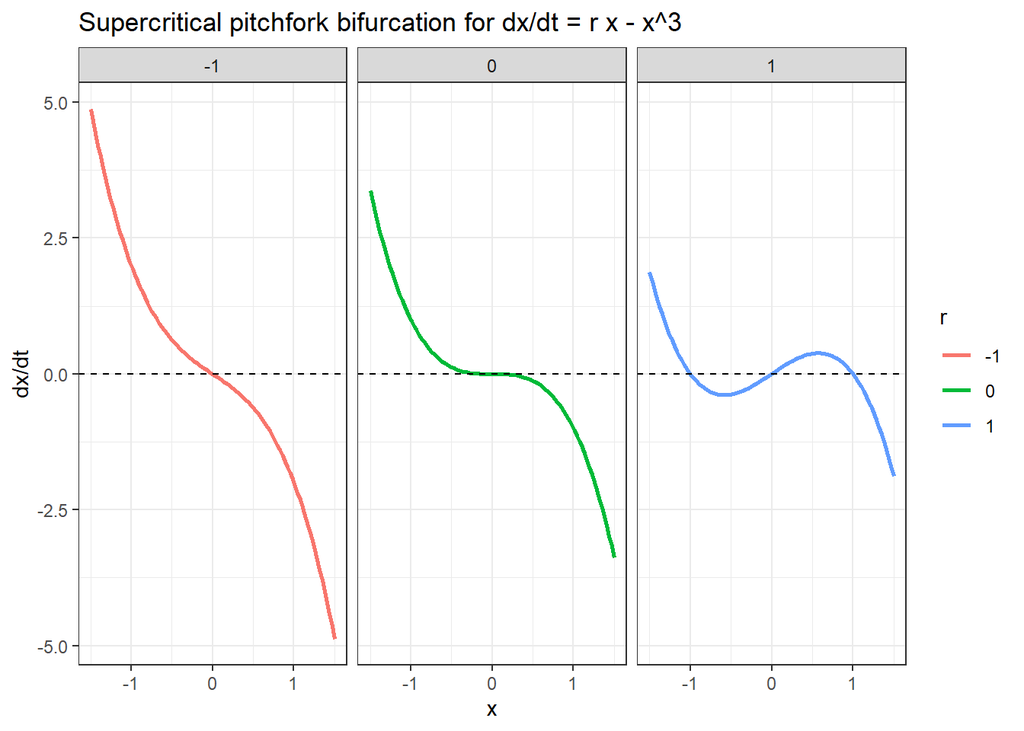

```r
supercritical_map <- function(x, r) {
  return(r * x - x^3)
}

r_values <- c(-1,0,1)
x_vals <- seq(-1.5, 1.5, length.out = 100)
dx_dt_df <- NULL  # Initialize as empty data frame

for (r in r_values) {
  df_aux <- data.frame(
    x = x_vals,
    dx_dt = supercritical_map(x_vals, r),
    r = r)
  dx_dt_df <- rbind(dx_dt_df, df_aux)  # Append new rows

}

ggplot(data = dx_dt_df,
       aes(x = x, y = dx_dt, color = as.factor(r))) +
  geom_line(linewidth = 1) +
  geom_hline(yintercept = 0, linetype = "dashed") +
  labs(title = "Supercritical pitchfork bifurcation for dx/dt = r x - x^3",
       x = "x", y = "dx/dt", color = "r") +
  facet_grid(~r)+
  theme_bw()
```

## **1.3 Bifurcation diagram**

To visualize how the nature of the roots depends on $r$, we plot the fixed points of the system against $r$, using colors to indicate stability:

- **Blue** = Stable equilibrium
- **Red** = Unstable equilibrium

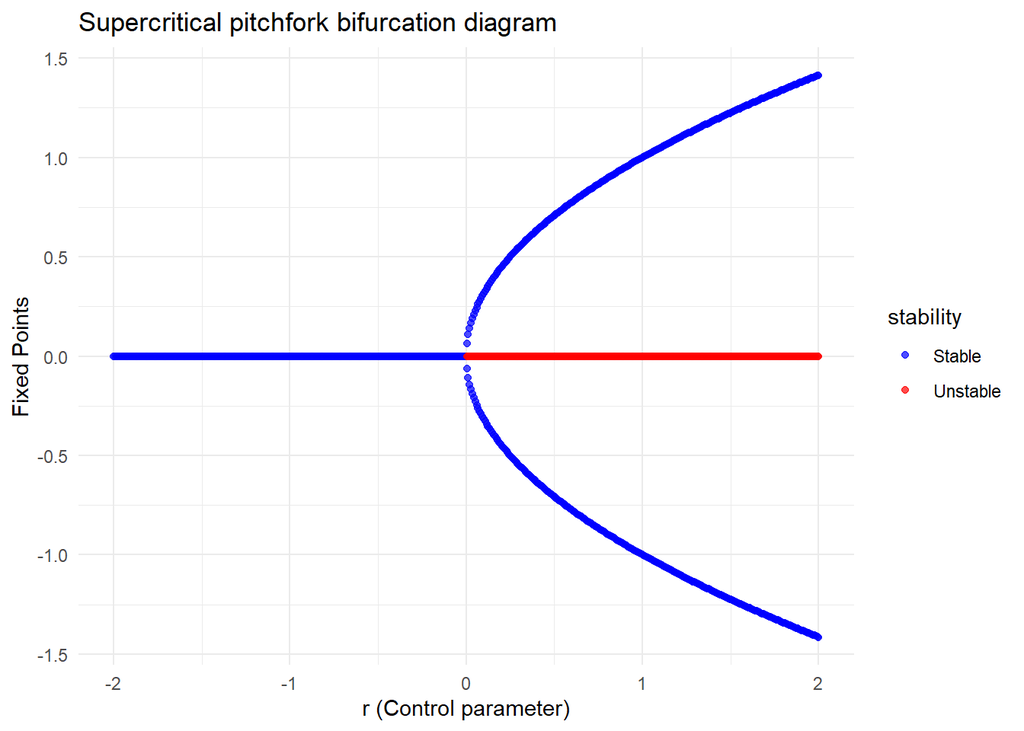

```r
supercritical_map <- function(x, r) {
  return(r * x - x^3)
}

fixed_points_supercritical <- function(r) {
  roots <- polyroot(c(0,r,0,-1))
  real_roots <- roots[round(Im(roots),10)==0]
  return(Re(real_roots))
}

stability_supercritical <- function(x, r) {
  derivative <- r - 3 * x^2
  if (derivative < 0) "Stable" else "Unstable"
}

r_values <- seq(-2, 2, length.out = 500)
bifurcation_data <- NULL #Empty variable to store bifurcation data

for (r in r_values) {
  points_super <- fixed_points_supercritical(r)
  for (x in points_super) {
    bifurcation_data <- rbind(bifurcation_data,
                              data.frame(r = r,
                                         x = x,
                                         stability = stability_supercritical(x, r)
                                         )
                              )
  }
}

ggplot(bifurcation_data, aes(x = r, y = x, color = stability)) +
  geom_point(size = 1.5, alpha = 0.7) +
  scale_color_manual(values = c("Stable" = "blue", "Unstable" = "red")) +
  labs(title = "Supercritical pitchfork bifurcation diagram",
       x = "r (Control parameter)", y = "Fixed Points") +
  theme_minimal()
```

# 2. Subcritical pitchfork bifurcation

## **2.1 Theoretical background**

A **subcritical pitchfork bifurcation** is characterized by an unstable fixed point that merges with a stable one as the control parameter $r$ changes. The system under study is:

$$\begin{aligned}
\dot{x} &= r \cdot x + x^3
\end{aligned}$$

The fixed points of this system are:

$$x^* = 0, \quad \pm\sqrt{-r}$$

## **2.2 Bifurcation diagram**

To visualize how the nature of the roots depends on $r$, we plot the fixed points of the system against $r$, using colors to indicate stability:

- **Blue** = Stable equilibrium
- **Red** = Unstable equilibrium

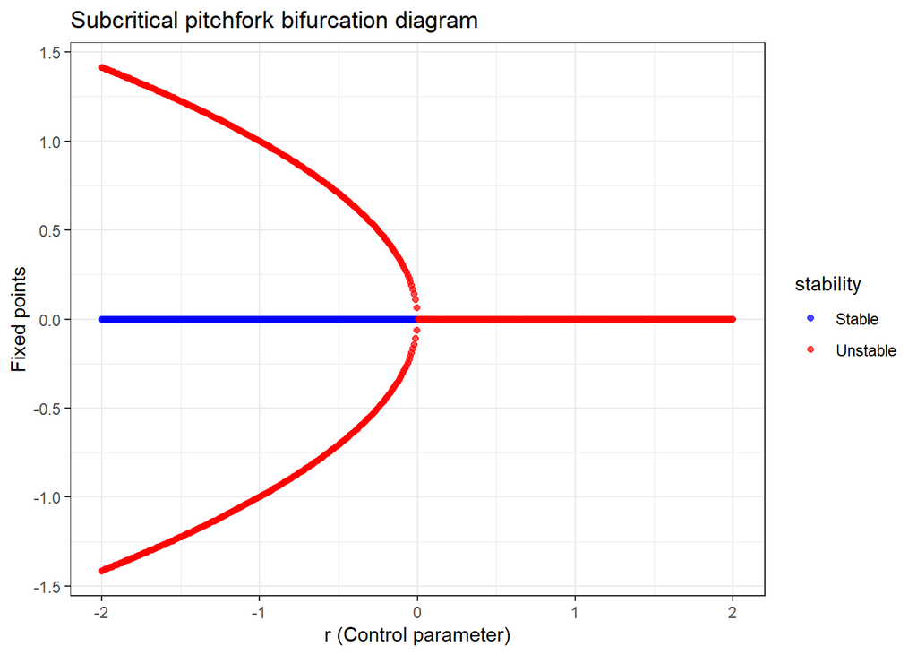

```r
subcritical_map <- function(x, r) {
  return(r * x + x^3)
}

fixed_points_subcritical <- function(r) {
  roots <- polyroot(c(0,r,0,1))
  real_roots <- roots[round(Im(roots),10)==0]
  return(Re(real_roots))
}

stability_subcritical <- function(x, r) {
  derivative <- r + 3 * x^2
  if (derivative < 0) "Stable" else "Unstable"
}

r_values <- seq(-2, 2, length.out = 500)
bifurcation_data <- NULL #Empty variable to store bifurcation data

for (r in r_values) {
  points_sub <- fixed_points_subcritical(r)
  for (x in points_sub) {
    bifurcation_data <- rbind(bifurcation_data,
                              data.frame(r = r,
                                         x = x,
                                         stability = stability_subcritical(x, r)
                                         )
                              )
  }
}

ggplot(bifurcation_data, aes(x = r, y = x, color = stability)) +
  geom_point(size = 1.5, alpha = 0.7) +
  scale_color_manual(values = c("Stable" = "blue", "Unstable" = "red")) +
  labs(title = "Subcritical pitchfork bifurcation diagram",
       x = "r (Control parameter)", y = "Fixed points") +
  theme_bw()
```

# 3. Saddle-Node bifurcation

## **3.1 Theoretical background**

A **saddle-Node bifurcation** occurs when two fixed points (one stable and one unstable) collide and annihilate each other as the control parameter $r$ crosses a critical value. Consider the system:

$$\begin{aligned}
\dot{x} &= r - x^2
\end{aligned}$$

The fixed points of this system are:

$$x^* \pm\sqrt{r}$$

Depending on the value of $r$:

- **Case A**: $r < 0$ → No real fixed points, so the system does not have equilibrium solutions..
- **Case B**: $r = 0$ → A single real fixed point at $x^*=0$. This is the point at which two fixed points collide.
- **Case C**: $r > 0$ → Two real fixed points appear:$x^*= + \sqrt{r}$ and $x^*= - \sqrt{r}$. One will be stable, and the other unstable, reflecting the “saddle” (unstable) and “node” (stable) nature.

The stability can be determined by evaluating the derivative of the right-hand side:

$$\frac{d }{dt}(r-x^2)=-2\cdot x$$

- If **$-2\cdot x<0$**, the fixed point is **stable**.
- If **$-2\cdot x>0$**, the fixed point is **unstable**.

## **3.2 Phase portraits for different $r$**

Similar to the supercritical case, we can plot $\dot{x} = r - x^2$ as a function of $x$ for representative values of $r$. Note how the number of intersections with $\dot{x} =0$ changes from no intersection (when $r < 0$) to one intersection at $r = 0$, and two intersections (one stable, one unstable) when $r > 0$.

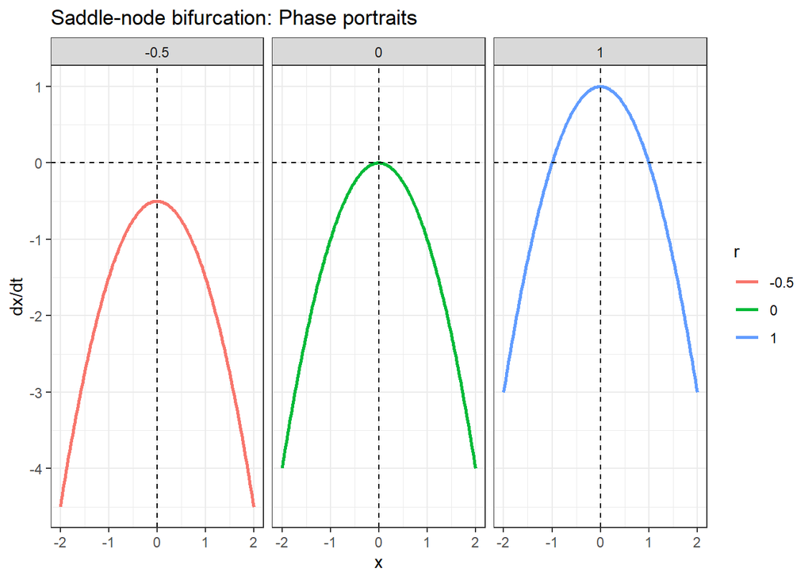

```r
# Phase portrait function
saddle_node_map <- function(x, r) {
  return(r - x^2)
}

# Choose representative values of r
r_values <- c(-0.5, 0, 1)
x_vals <- seq(-2, 2, length.out = 200)

# Build data frame for plotting
df_phase <- data.frame()

for (r in r_values) {
  df_temp <- data.frame(
    x = x_vals,
    dx_dt = saddle_node_map(x_vals, r),
    r = as.factor(r)
  )
  df_phase <- rbind(df_phase, df_temp)
}

library(ggplot2)

ggplot(df_phase, aes(x = x, y = dx_dt, color = r)) +
  geom_line(linewidth = 1) +
  geom_vline(xintercept = 0, linetype = "dashed") +
  geom_hline(yintercept = 0, linetype = "dashed") +
  labs(title = "Saddle-node bifurcation: Phase portraits",
       x = "x", y = "dx/dt", color = "r") +
  facet_grid(~r) +
  theme_bw()
```

## **3.3 Bifurcation diagram**

Finally, we construct the bifurcation diagram by identifying the fixed points across a range of $r$ values and coloring them according to their stability:

- **Blue** = Stable equilibrium
- **Red** = Unstable equilibrium

Notice how, for $r > 0$, two branches appear (stable and unstable), and for $r < 0$, there is no real fixed point.

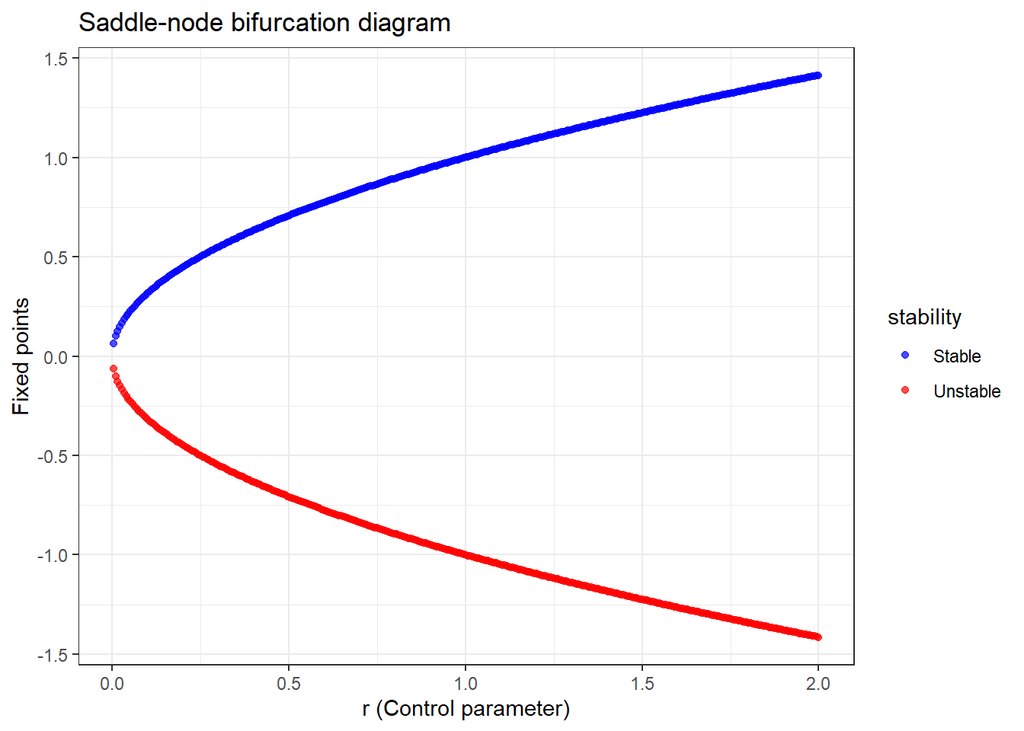

```r
# map_function <- function(x, r) {
#   return(r - x^2)
# }

fixed_points_saddle_node <- function(r) {
  roots <- polyroot(c(r,0,-1))
  real_roots <- roots[round(Im(roots),10)==0]
  return(Re(real_roots))
}

stability_saddle_node <- function(x, r) {
  derivative <- -2 * x
  if (derivative < 0) "Stable" else "Unstable"
}

r_values <- seq(-1, 2, length.out = 500)
bifurcation_data <- NULL #Empty variable to store bifurcation data

for (r in r_values) {
  points <- fixed_points_saddle_node(r)
  for (x in points) {
    bifurcation_data <- rbind(bifurcation_data,
                              data.frame(r = r,
                                         x = x,
                                         stability = stability_saddle_node(x, r)
                                         )
                              )
  }
}

ggplot(bifurcation_data, aes(x = r, y = x, color = stability)) +
  geom_point(size = 1.5, alpha = 0.7) +
  scale_color_manual(values = c("Stable" = "blue", "Unstable" = "red")) +
  labs(title = "Saddle-node bifurcation diagram",
       x = "r (Control parameter)", y = "Fixed points") +
  theme_bw()
```

# 4. Transcritical Bifurcation

## **4.1 Theoretical background**

A **transcritical bifurcation** occurs when two fixed points exchange their stability as a parameter is varied. Unlike the saddle-node bifurcation, in the transcritical case both fixed points exist for all parameter values, but their stability changes at the critical point. Consider the system:

Consider the system:

$$\dot{x} = rx - x^2$$

This system has two fixed points:

- $x^* = 0$
- $x^* = r$

The stability of fixed points depend on the value of $r$:

- At $x^* = 0$: $\left.\frac{d}{dx}(rx - x^2)\right|_{x^*=0} = r$
- At $x^* = r$: $\left.\frac{d}{dx}(rx - x^2)\right|_{x^*=r} = -r$

Therefore:

- If $r < 0$, $x^*=0$ is stable and $x^*=r$ is unstable.
- If $r > 0$, $x^*=0$ is unstable and $x^*=r$ is stable.
- At $r=0$, both fixed points coincide and exchange stability.

## **4.2 Phase portraits for different $r$**

By plotting $\dot{x}$ versus $x$, we observe the change in stability of the fixed points $x^*=0$ and $x^*=r$. When $r = -1$, the origin is stable; when $r = 1$, the roles are reversed: the origin becomes unstable and the other fixed point is stable.

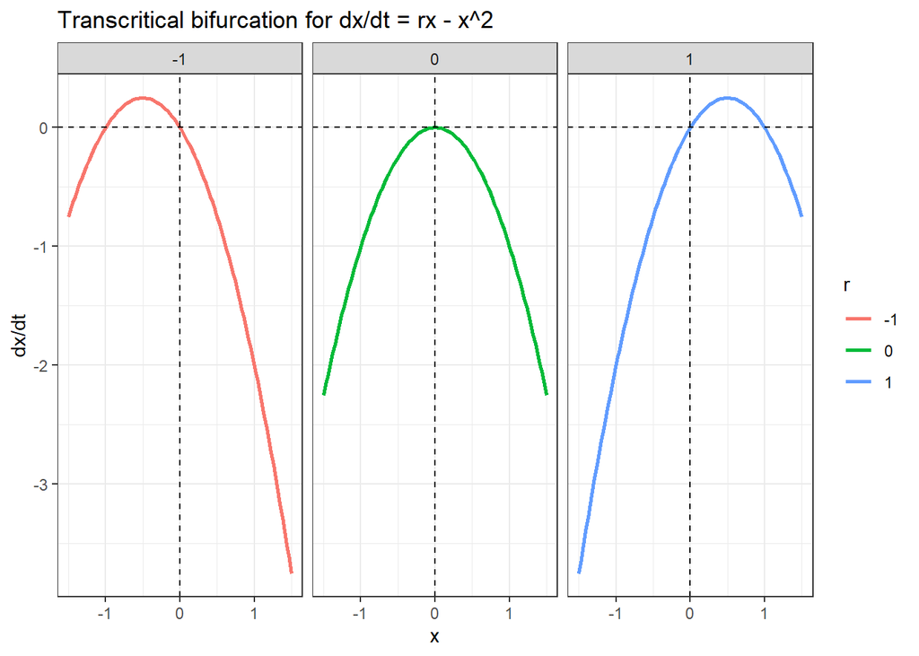

```r
transcritical_map <- function(x, r) {
  return(r*x  - x^2)
}

r_values <- c(-1,0,1)
x_vals <- seq(-1.5, 1.5, length.out = 100)
dx_dt_df <- NULL  # Initialize as empty data frame

for (r in r_values) {
  df_aux <- data.frame(
    x = x_vals,
    dx_dt = transcritical_map(x_vals, r),
    r = r)
  dx_dt_df <- rbind(dx_dt_df, df_aux)  # Append new rows

}

ggplot(data = dx_dt_df,
       aes(x = x, y = dx_dt, color = as.factor(r))) +
  geom_line(linewidth = 1) +
  geom_vline(xintercept = 0, linetype = "dashed") +
  geom_hline(yintercept = 0, linetype = "dashed") +
  labs(title = "Transcritical bifurcation for dx/dt = rx - x^2",
       x = "x", y = "dx/dt", color = "r") +
  facet_grid(~r)+
  theme_bw()
```

## **4.3 Bifurcation diagram**

Finally, we build the bifurcation diagram by tracking the fixed points as the parameter $r$ varies, and we color-code them based on their stability:

- **Blue** = Stable equilibrium
- **Red** = Unstable equilibrium

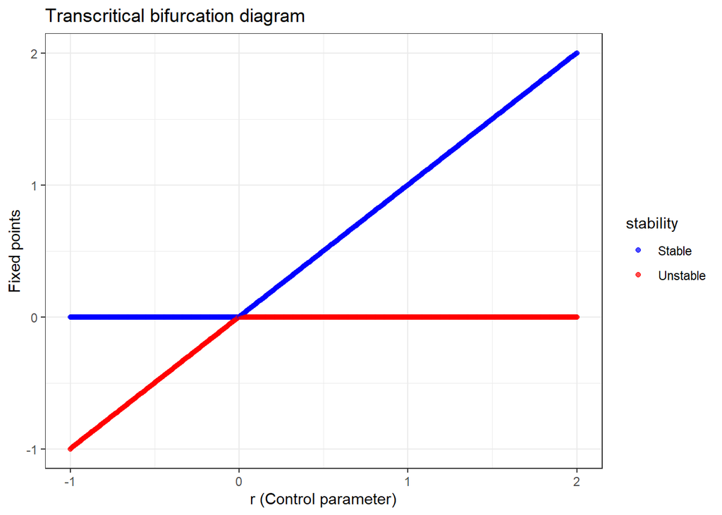

```r
# map_function <- function(x, r) {
#   return(r*x - x^2)
# }

fixed_points_transcritical_map <- function(r) {
  roots <- polyroot(c(0,r,-1))
  real_roots <- roots[round(Im(roots),10)==0]
  return(Re(real_roots))
}

stability_transcritical_map <- function(x, r) {
  derivative <- r -2 * x
  if (derivative < 0) "Stable" else "Unstable"
}

r_values <- seq(-1, 2, length.out = 500)
bifurcation_data <- NULL #Empty variable to store bifurcation data

for (r in r_values) {
  points <- fixed_points_transcritical_map(r)
  for (x in points) {
    bifurcation_data <- rbind(bifurcation_data,
                              data.frame(r = r,
                                         x = x,
                                         stability = stability_transcritical_map(x, r)
                                         )
                              )
  }
}

ggplot(bifurcation_data, aes(x = r, y = x, color = stability)) +
  geom_point(size = 1.5, alpha = 0.7) +
  scale_color_manual(values = c("Stable" = "blue", "Unstable" = "red")) +
  labs(title = "Transcritical bifurcation diagram",
       x = "r (Control parameter)", y = "Fixed points") +
  theme_bw()
```

# Exercise

This pactice exercise is focused on characterizing the **subcritical pitchfork bifurcation** of the system:

$$\dot{x} = r\,x + x^3 - x^5.$$

1. **Find the Equilibrium Points**
   - Write down the equilibrium equation $\dot{x} = 0$.
   - Factorize the polynomial to identify the solutions for $x$ and see how they depend on $r$.
2. **Stability Analysis**
   - For each equilibrium $x^*$, compute the derivative $\frac{d}{dx}(r\,x + x^3 - x^5) = r + 3x^2 - 5x^4$.
   - Conclude whether the equilibrium is **stable** (derivative < 0) or **unstable** (derivative > 0).
3. **Sketch Phase Portraits**
   - Choose representative values of $r$ (negative, zero, positive).
   - Plot $\dot{x}$ vs. $x$ in R, identify where $\dot{x} = 0$, and mark equilibria as stable or unstable.
4. **Numerical Bifurcation Diagram**
   - Adapt or run the R script above, which uses polynomial root-finding (`polyroot`) to locate equilibria.
   - Color them by stability and plot them against $r$.
5. **Interpret the Results**
   - Identify the critical parameter value(s) of $r$ that cause a subcritical pitchfork bifurcation.
   - Compare to the simpler subcritical system $\dot{x} = r\,x + x^3$ to see how the additional $-x^5$ term changes the bifurcation structure.